# **Da Pergunta ao Resultado: Um Guia para Iniciantes**

Manual do Cientísta

2025-09-30

# **Metódo científico**

Este projeto foi elaborado com o objetivo de servir como um **guia prático** para alunos de iniciação científica e pós-graduação, auxiliando-os a compreender e aplicar o método científico de forma estruturada. Ele apresenta o passo a passo de um projeto científico, desde a formulação de uma **pergunta de pesquisa clara**, passando pelo desenvolvimento de **hipóteses e predições**, até a **coleta e análise de dados** e a **interpretação dos resultados**.

O intuito é que os estudantes possam visualizar de forma concreta como transformar uma questão científica em um estudo bem planejado, entendam um desenho experimental e a aplicação de um experimento. Bem como aprendam a organizar seus dados, escolher modelos estatísticos apropriados e representar os resultados de forma clara e didática. Além disso, o projeto pode ser facilmente replicado no “mundo real”, por ser simples e utilizar materiais acessíveis e procedimentos diretos. Dessa forma, se o pesquisador entender o processo e aplicar com clareza vai permitir que ele realize suas próprias experiências e compreenda cada etapa do processo científico de maneira prática.

Este guia também serve como referência para entender a importância de cada etapa do método científico e como organizá-lo de maneira estruturada, promovendo o aprendizado ativo e a aplicação prática do conhecimento científico.

## **Vamos definir a pergunta, hipótese e predição!**

### **Pergunta**

A definição de uma pergunta de pesquisa clara é o primeiro passo fundamental de qualquer projeto científico, pois ela orienta todo o desenho experimental. Neste estudo, a pergunta é: **Conseguimos acertar se a bala tem sabor ruim ou bom apenas pelo seu cheiro?** Uma pergunta bem formulada permite que o pesquisador saiba exatamente o que deseja investigar e facilita a escolha das variáveis e métodos adequados.

### **Hipóteses**

Uma hipótese é a possível resposta à pergunta de pesquisa, baseada em observações prévias e/ou em conhecimento teórico. Formular hipóteses ajuda a direcionar o estudo e determinar quais as variáveos importantes e como esses dados serão analisados. Para este experimento, a hipótese principal é: **A frequência de acertos sobre o sabor da bala (bom ou ruim) será maior quando os participantes cheirarem a bala.**

### **Predições - Hipóteses estatísticas**

Definir essas hipóteses é essencial para planejar os testes estatísticos e estabelecer critérios claros para rejeitar ou não H0, garantindo que as conclusões do estudo sejam baseadas em evidências.

**Hipótese nula (H0)**: A frequência de acertos sobre o sabor da bala será igual cheirando ou não a bala. *Representa a ausência de efeito do tratamento.*

**Hipótese alternativa (H1)**: A frequência de acertos sobre o sabor da bala será maior quando os participantes cheirarem a bala. *Representa a expectativa de efeito do tratamento.*

Para avaliar a hipótese de forma objetiva, operacionalizamos e transformamos a hipótese em termos estatísticos, o que permite avaliar as variáveis, se todas estão sendo coletadas e pensar como interpretar os resultados quantitativos.

#### *Nível de significância: α = 0,05 (p < 0,05 → rejeita H0)*

# **Metodologia**

O experimento foi planejado para testar a hipótese de que **a frequência de acertos sobre o sabor da bala será maior quando os participantes cheirarem a bala**. Seis participantes adultos voluntários participaram do estudo. Cada um deles experimentou um total de 10 balas da marca **Bean Boozled**, comercialmente conhecidas por apresentarem sabores agradáveis ou desagradáveis de forma aleatória. Todas as balas foram retiradas do mesmo pacote, garantindo que o tipo e a condição fossem padronizados.

O estudo foi conduzido em ambiente controlado, o mesmo para todos os participantes, garantindo condições semelhantes de percepção sensorial.Foram realizados dois tratamentos distintos: No primeiro, denominado controle, as balas foram apresentadas em ordem aleatória e os participantes davam o palpite se a bala era boa ou ruim sem cheirar. No segundo, chamado “cheirar”, as balas foram apresentadas da mesma forma, mas os participantes puderam cheirar a bala antes de dar o palpite sobre o seu sabor. Durante cada tentativa, foram registrados os acertos, quando o participante identificou corretamente o sabor da bala e os erros, quando o participante não identificou corretamente o sabor da bala. Dessa forma, foi possível avaliar se o cheiro influenciava a percepção de sabor desagradável. Cada participante realizou ambos os tratamentos, permitindo analisar medidas repetidas e controlar a variação individual.

Este desenho experimental possibilitou comparar tanto a proporção de acertos quanto a proporção de vezes que os participantes relataram o sabor como ruim.

# **Importar dados e estrutura dos dados**

## **Ecolher diretório**

Vamos mostrar a pasta que seu arquivo está.

```r
setwd("C:/Users/grazi/Downloads")
```

## **Importar planilha de dados**

```r
library(readxl)
dados <- read_excel("dados bala roleta russa.xlsx",
    sheet = "Planilha2")

# Conferir estrutura dos dados
# Vamos ver a estrutura dos dados das planilhas dune e dune.env
names(dados)
```

```
## [1] "bala"         "participante" "tratamento"   "acertos"      "tentativas"
## [6] "N_falou_ruim"
```

```r
str(dados)
```

```
## tibble [12 × 6] (S3: tbl_df/tbl/data.frame)
##  $ bala        : num [1:12] 1 1 2 2 3 3 4 4 5 5 ...
##  $ participante: chr [1:12] "claudio" "claudio" "Grazi" "Grazi" ...
##  $ tratamento  : chr [1:12] "cheirou" "aleatório" "cheirou" "aleatório" ...
##  $ acertos     : num [1:12] 3 2 2 2 3 3 1 2 3 3 ...
##  $ tentativas  : num [1:12] 5 5 5 5 5 5 5 5 5 5 ...
##  $ N_falou_ruim: num [1:12] 4 2 4 3 4 2 4 2 4 2 ...
```

```r
# Corrigir estrutura dos dados

library(dplyr)
dados <- dados %>%
  mutate(
    across(where(is.numeric), as.integer),
    across(where(is.character), as.factor))

str(dados)
```

```
## tibble [12 × 6] (S3: tbl_df/tbl/data.frame)
##  $ bala        : int [1:12] 1 1 2 2 3 3 4 4 5 5 ...
##  $ participante: Factor w/ 6 levels "claudio","Eloa",..: 1 1 3 3 6 6 2 2 4 4 ...
##  $ tratamento  : Factor w/ 2 levels "aleatório","cheirou": 2 1 2 1 2 1 2 1 2 1 ...
##  $ acertos     : int [1:12] 3 2 2 2 3 3 1 2 3 3 ...
##  $ tentativas  : int [1:12] 5 5 5 5 5 5 5 5 5 5 ...
##  $ N_falou_ruim: int [1:12] 4 2 4 3 4 2 4 2 4 2 ...
```

# **Análise de dados**

**Modelos lineares generalizados mistos (GLMMs)**

Para testar nossa hipótese, utilizamos um **Modelo Linear Generalizado Misto (GLMM)**, que permite analisar dados com características específicas que modelos lineares comuns não conseguem tratar. Neste experimento, cada participante experimentou a mesma bala em **dois tratamentos diferentes**, configurando um caso de **medidas repetidas**. Para lidar com essa dependência entre observações do mesmo indivíduo, incluímos **o participante como efeito aleatório**, o que controla a variação individual e evita que diferenças entre pessoas influenciem os resultados do tratamento.

Além disso, como cada participante realizou um número fixo de tentativas (5), transformamos os dados em proporções de acertos em relação ao total de tentativas. Esse tipo de dado é melhor modelado usando a distribuição de erros binomial, apropriada para variáveis que representam “sucessos” em um número fixo de tentativas. O GLMM nos permite assim estimar se o tratamento (cheirar ou não a bala) influencia a proporção de acertos, considerando simultaneamente a variação entre participantes e a natureza binomial do dado.

## **Efeito do tratamento na proporção de acertos**

```r
library(lme4)
names(dados)
```

```
## [1] "bala"         "participante" "tratamento"   "acertos"      "tentativas"
## [6] "N_falou_ruim"
```

```r
# modelo completo
m1 <- glmer(cbind(acertos, tentativas - acertos) ~ tratamento + (1 | participante), data = dados,family = binomial)
```

```
## boundary (singular) fit: see help('isSingular')
```

```r
# modelo nulo
m1_nulo <- glmer(cbind(acertos, tentativas - acertos) ~ 1 + (1 | participante),data = dados,family = binomial)
```

```
## boundary (singular) fit: see help('isSingular')
```

```r
# Checar pressupostos
library(easystats)
library(performance)

check_overdispersion(m1)
```

```
## # Overdispersion test
##
##  dispersion ratio = 0.360
##           p-value = 0.032
```

```
## Underdispersion detected.
```

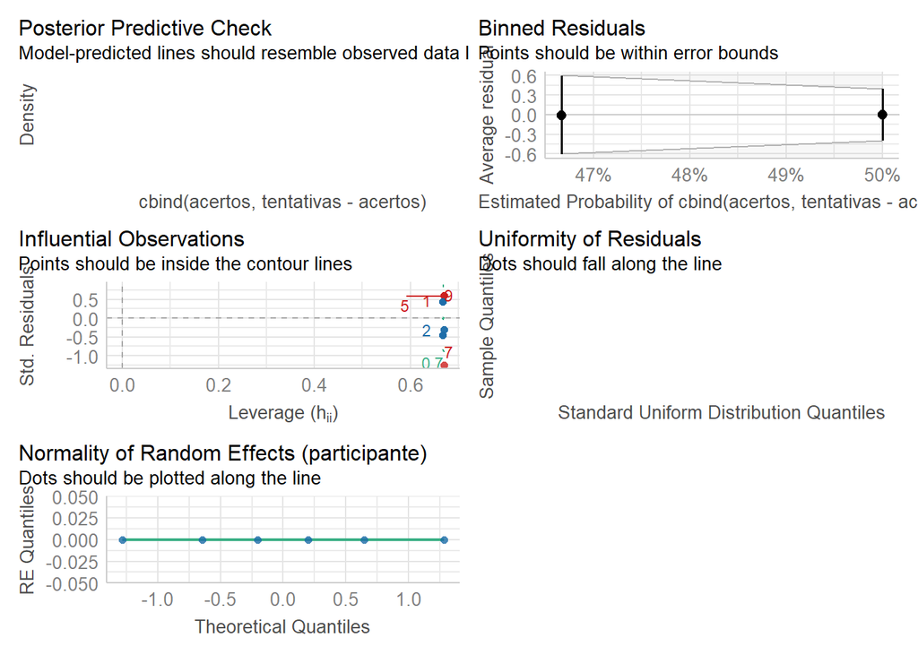

```r
check_model(m1)
```

```r
# Os resíduos do nosso modelo estão ok.
# Vamos vere o resultado
resultado<-anova(m1,m1_nulo)
resultado
```

```
## Data: dados
## Models:
## m1_nulo: cbind(acertos, tentativas - acertos) ~ 1 + (1 | participante)
## m1: cbind(acertos, tentativas - acertos) ~ tratamento + (1 | participante)
##         npar    AIC    BIC  logLik deviance  Chisq Df Pr(>Chisq)
## m1_nulo    2 33.235 34.205 -14.618   29.235
## m1         3 35.168 36.623 -14.584   29.169 0.0668  1     0.7961
```

```r
# Reportar resultado
library(report)
report(m1)
```

```
## boundary (singular) fit: see help('isSingular')
```

```
## Random effect variances not available. Returned R2 does not account for random effects.
## Can't calculate log-loss.
```

```
## Can't calculate proper scoring rules for models without integer response
##   values.
```

```
## boundary (singular) fit: see help('isSingular')
```

```
## Random effect variances not available. Returned R2 does not account for random effects.
## Can't calculate log-loss.
```

```
## Can't calculate proper scoring rules for models without integer response
##   values.
```

```
## We fitted a logistic mixed model (estimated using ML and Nelder-Mead optimizer)
## to predict cbind(acertos, tentativas - acertos) with tratamento (formula:
## cbind(acertos, tentativas - acertos) ~ tratamento). The model included
## participante as random effect (formula: ~1 | participante). The model's
## explanatory power related to the fixed effects alone (marginal R2) is 1.48e-03.
## The model's intercept, corresponding to tratamento = aleatório, is at 5.74e-17
## (95% CI [-0.72, 0.72], p > .999). Within this model:
##
##   - The effect of tratamento [cheirou] is statistically non-significant and
## negative (beta = -0.13, 95% CI [-1.15, 0.88], p = 0.796; Std. beta = -0.13, 95%
## CI [-1.15, 0.88])
##
## Standardized parameters were obtained by fitting the model on a standardized
## version of the dataset. 95% Confidence Intervals (CIs) and p-values were
## computed using a Wald z-distribution approximation.
```

## **Criar tabela com o resultado**

Apresentar os resultados do modelo em uma **tabela organizada** é fundamental para a clareza e a compreensão do leitor. Com a tabela, é possível visualizar de forma rápida e direta informações essenciais, como os diferentes modelos testados, o número de parâmetros, medidas de ajuste (AIC, BIC), logaritmo da verossimilhança, deviance, estatísticas de comparação entre modelos e valores de p.

Essa forma de apresentação permite que o leitor compare os modelos de forma objetiva, entenda quais variáveis explicativas tiveram efeito significativo, e acompanhe o raciocínio do pesquisador sem precisar interpretar apenas o código ou descrições textuais longas. Além disso, uma tabela bem estruturada aumenta a transparência e reprodutibilidade do estudo, facilitando que outros pesquisadores possam replicar a análise ou usar os resultados como referência.

```r
library(dplyr)
library(knitr)

tabela_modelo <- resultado %>%
  tibble::rownames_to_column("Modelo") %>%
  mutate(
    Variável_Resposta    = "Acertos",
    Variável_Explicativa = "Tratamento",
    Distribuição         = "Binomial"
  ) %>%
  select(
    "Variável Resposta"    = Variável_Resposta,
    "Variável Explicativa" = Variável_Explicativa,
    "Distribuição"         = Distribuição,
    Modelo,
    npar, AIC, BIC, logLik, Deviance = deviance, Chisq, Df, `Pr(>Chisq)`
  )

# Gerar tabela formatada
kable(
  tabela_modelo,
  caption = "Comparação entre modelos GLMM binomiais",
  digits = 3,
  align = "c"
)
```

Comparação entre modelos GLMM binomiais

| Variável Resposta | Variável Explicativa | Distribuição | Modelo | npar | AIC | BIC | logLik | Deviance | Chisq | Df | Pr(>Chisq) |
| --- | --- | --- | --- | --- | --- | --- | --- | --- | --- | --- | --- |
| Acertos | Tratamento | Binomial | m1_nulo | 2 | 33.235 | 34.205 | -14.618 | 29.235 | NA | NA | NA |
| Acertos | Tratamento | Binomial | m1 | 3 | 35.168 | 36.623 | -14.584 | 29.168 | 0.067 | 1 | 0.796 |

## **Gráfico - proporção de acertos**

```r
library(emmeans)
```

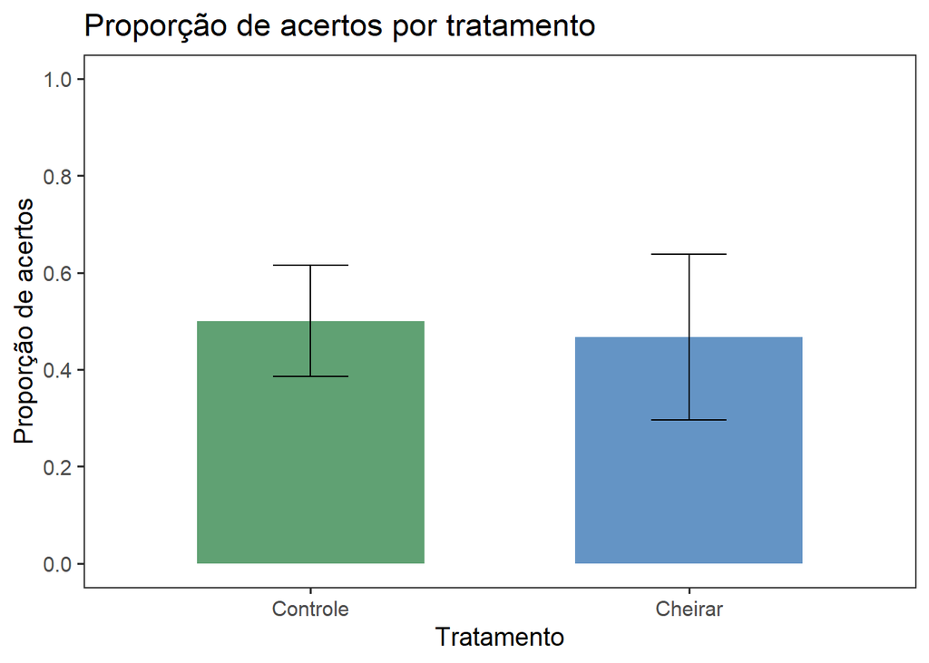

```r
library(ggplot2)

library(dplyr)

# Criar coluna de proporção de acertos
dados <- dados %>%
  mutate(prop = acertos / tentativas)


library(ggplot2)

library(ggplot2)
library(dplyr)

# Certifique-se de ter a coluna de proporção
dados <- dados %>% mutate(prop = acertos / tentativas)

ggplot(dados, aes(x = tratamento, y = prop, fill = tratamento)) +

  # Barras com média
  stat_summary(
    fun = mean,
    geom = "bar",
    alpha = 0.7,
    width = 0.6
  ) +

  # Intervalo de confiança 95%
  stat_summary(
    fun.data = mean_cl_normal,
    geom = "errorbar",
    width = 0.2,
    color = "black"
  ) +

  # Escalas de cores e preenchimento
  scale_fill_manual(name = "Tratamento",
                    values = c("cheirou" = "#2166ac",
                               "aleatório" = "#1b7837"),
                    labels = c("Cheirar", "Controle")) +
  scale_color_manual(name = "Tratamento",
                     values = c("cheirou" = "#2166ac",
                                "aleatório" = "#1b7837"),
                     labels = c("Cheirar",
                                "Controle")) +

  # Rótulos do eixo X
  scale_x_discrete(labels = c("Controle", "Cheirar")) +

  # Eixo Y
  scale_y_continuous(limits = c(0,1), breaks = seq(0,1,0.2)) +

  # Rótulos e título
  labs(
    x = "Tratamento",
    y = "Proporção de acertos",
    title = "Proporção de acertos por tratamento"
  )+

  theme_test(base_size = 14) +
  theme(legend.position = "none")
```

## **Efeito do tratamento sobre percepção do sabor ruim**

```r
library(lme4)
names(dados)
```

```
## [1] "bala"         "participante" "tratamento"   "acertos"      "tentativas"
## [6] "N_falou_ruim" "prop"
```

```r
# modelo completo
m2 <- glmer(cbind(N_falou_ruim, tentativas - N_falou_ruim) ~ tratamento + (1 | participante), data = dados, family = binomial)
```

```
## boundary (singular) fit: see help('isSingular')
```

```r
# modelo nulo
m2_nulo <- glmer(cbind(N_falou_ruim, tentativas - N_falou_ruim) ~ 1 + (1 | participante),data = dados,family = binomial)
```

```
## boundary (singular) fit: see help('isSingular')
```

```r
# Checar pressupostos
library(easystats)
library(performance)

check_overdispersion(m2)
```

```
## # Overdispersion test
##
##  dispersion ratio = 0.409
##           p-value = 0.064
```

```
## No overdispersion detected.
```

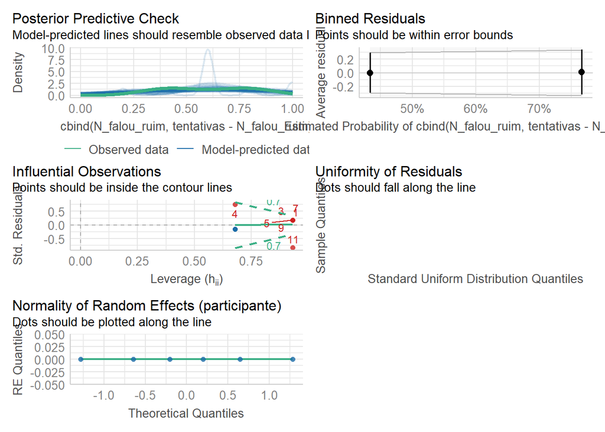

```r
check_model(m2)
```

```r
# Os resíduos do nosso modelo estão ok.
# Vamos vere o resultado
resultado<-anova(m2,m2_nulo)
resultado
```

```
## Data: dados
## Models:
## m2_nulo: cbind(N_falou_ruim, tentativas - N_falou_ruim) ~ 1 + (1 | participante)
## m2: cbind(N_falou_ruim, tentativas - N_falou_ruim) ~ tratamento + (1 | participante)
##         npar    AIC    BIC  logLik deviance  Chisq Df Pr(>Chisq)
## m2_nulo    2 36.431 37.401 -16.215   32.431
## m2         3 31.320 32.774 -12.660   25.320 7.1111  1   0.007661 **
## ---
## Signif. codes:  0 '***' 0.001 '**' 0.01 '*' 0.05 '.' 0.1 ' ' 1
```

```r
# Reportar resultado
library(report)
report(m2)
```

```
## boundary (singular) fit: see help('isSingular')
```

```
## Random effect variances not available. Returned R2 does not account for random effects.
## Can't calculate log-loss.
```

```
## Can't calculate proper scoring rules for models without integer response
##   values.
## boundary (singular) fit: see help('isSingular')
```

```
## Random effect variances not available. Returned R2 does not account for random effects.
## Can't calculate log-loss.
```

```
## Can't calculate proper scoring rules for models without integer response
##   values.
```

```
## We fitted a logistic mixed model (estimated using ML and Nelder-Mead optimizer)
## to predict cbind(N_falou_ruim, tentativas - N_falou_ruim) with tratamento
## (formula: cbind(N_falou_ruim, tentativas - N_falou_ruim) ~ tratamento). The
## model included participante as random effect (formula: ~1 | participante). The
## model's explanatory power related to the fixed effects alone (marginal R2) is
## 0.15. The model's intercept, corresponding to tratamento = aleatório, is at
## -0.27 (95% CI [-0.99, 0.45], p = 0.467). Within this model:
##
##   - The effect of tratamento [cheirou] is statistically significant and positive
## (beta = 1.46, 95% CI [0.35, 2.57], p = 0.010; Std. beta = 1.46, 95% CI [0.35,
## 2.57])
##
## Standardized parameters were obtained by fitting the model on a standardized
## version of the dataset. 95% Confidence Intervals (CIs) and p-values were
## computed using a Wald z-distribution approximation.
```

## **Gráfico - percepção do sabor ruim”**

Neste gráfico, visualizamos a proporção de tentativas em que cada participante relatou que a **bala tinha sabor ruim**, separadas pelos tratamentos. É possível ver que, no tratamento **“cheirou”**, essa proporção é maior do que no controle, indicando que os participantes **perceberam o odor e foram mais propensos a afirmar que o sabor era ruim**. Em conjunto, os gráficos mostram que, embora o cheiro tenha sido percebido pelos participantes, **isso não se traduziu em maior acerto na identificação do sabor**, possivelmente devido à propagação do odor entre as balas ou à percepção geral de que todas tinham cheiro ruim.

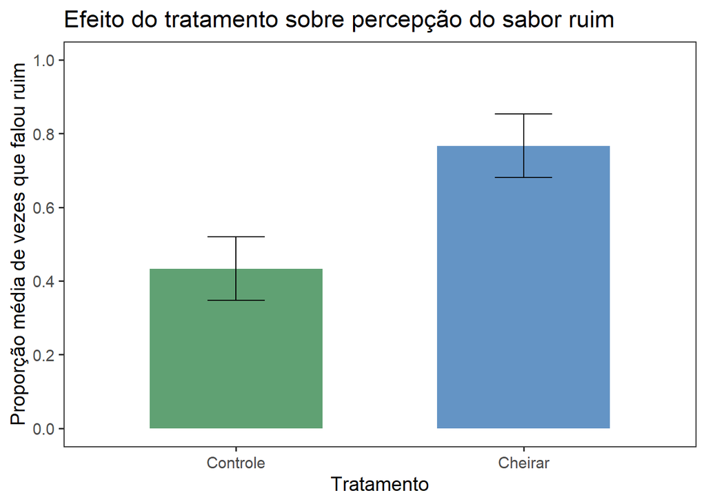

```r
library(emmeans)
library(ggplot2)
library(dplyr)

# Obter predições marginais do GLMM binomial com IC 95%
pred <- emmeans(m2, ~ tratamento, type = "response") %>%
  confint(level = 0.95) %>%   # adiciona lower.CL e upper.CL
  as.data.frame()

# Agora o gráfico de barras com IC
library(ggplot2)
library(dplyr)

# Certifique-se de ter a coluna de proporção
dados1 <- dados %>% mutate(prop_ruim = N_falou_ruim / tentativas)

ggplot(dados1, aes(x = tratamento, y = prop_ruim, fill = tratamento)) +

  # Barras com média
  stat_summary(
    fun = mean,
    geom = "bar",
    alpha = 0.7,
    width = 0.6
  ) +

  # Intervalo de confiança 95%
  stat_summary(
    fun.data = mean_cl_normal,
    geom = "errorbar",
    width = 0.2,
    color = "black"
  ) +

  # Escalas de preenchimento e rótulos
  scale_fill_manual(values = c("cheirou" = "#2166ac",
                               "aleatório" = "#1b7837"),
                    labels = c("Cheirar",
                               "Controle")) +
  scale_x_discrete(labels = c("Controle",
                              "Cheirar")) +
  scale_y_continuous(limits = c(0,1), breaks = seq(0,1,0.2)) +

  labs(
    x = "Tratamento",
    y = "Proporção média de vezes que falou ruim",
    title = "Efeito do tratamento sobre percepção do sabor ruim"
  ) +

  theme_test(base_size = 14) +
  theme(legend.position = "none")
```

# **Resultado**

O tratamento “cheirou” não alterou a proporção de acertos, ou seja, os participantes identificaram as balas de forma semelhante ao tratamento controle. Entretanto, quando cheiraram a bala, eles relataram com mais frequência que o sabor era ruim, indicando que o odor foi percebido. De fato, ao analisarmos especificamente se o ato de cheirar influenciava as respostas, observamos que os participantes tendiam a dizer que a bala era ruim com mais frequência no tratamento “cheirou” do que no controle. Esses resultados sugerem que, embora o cheiro tenha sido detectado, ele não interferiu na capacidade de identificar a bala corretamente, possivelmente devido à propagação do odor entre as balas ou à percepção geral de que todas tinham cheiro ruim.

# **Fragilidades e vieses do experimento**

Embora o experimento tenha sido planejado de forma cuidadosa, ele apresenta algumas **fragilidades e possíveis vieses** que podem ter influenciado os resultados. O principal ponto é que o odor das balas pode ter se espalhado entre os participantes ou entre as próprias balas, dificultando a distinção clara entre os tratamentos. Isso pode ter levado os participantes a perceberem que todas as balas tinham cheiro ruim, independentemente do tratamento, reduzindo a capacidade de detectar diferenças reais.

Além disso, o tamanho da amostra foi pequeno, o que limita a generalização dos resultados e aumenta a influência de variações individuais nos dados. Cada participante realizou apenas um número fixo de tentativas, o que também reduz a variabilidade observada. Outro fator a considerar é o possível viés de expectativa, ou seja, os participantes podem ter antecipado que algumas balas seriam ruins, influenciando suas respostas, mesmo sem perceber o cheiro de fato. Em resumo, embora os resultados forneçam informações valiosas, é importante considerar essas limitações ao interpretar as conclusões e ao planejar estudos futuros.